# Data Analysis for PSA Results

Alex & Rusheel

29/03/2021

## Answers to Questions

**Determine the incremental cost-effectiveness ratio (ICER) of the intervention strategy compared with the control stategy.**

```
## [1] 27939.72
```

As we can see, the ICER is about €28,000. This would be acceptable if society were willing to pay €80,000 per QALY but not if society were willing to pay only €20,000 per QALY.

**Create an incremental cost-effectiveness plane and visualize the incremental effects (x-axis) and incremental costs (y-axis) of the intervention strategy compared with the control strategy. Provide a correct label for both axes.**

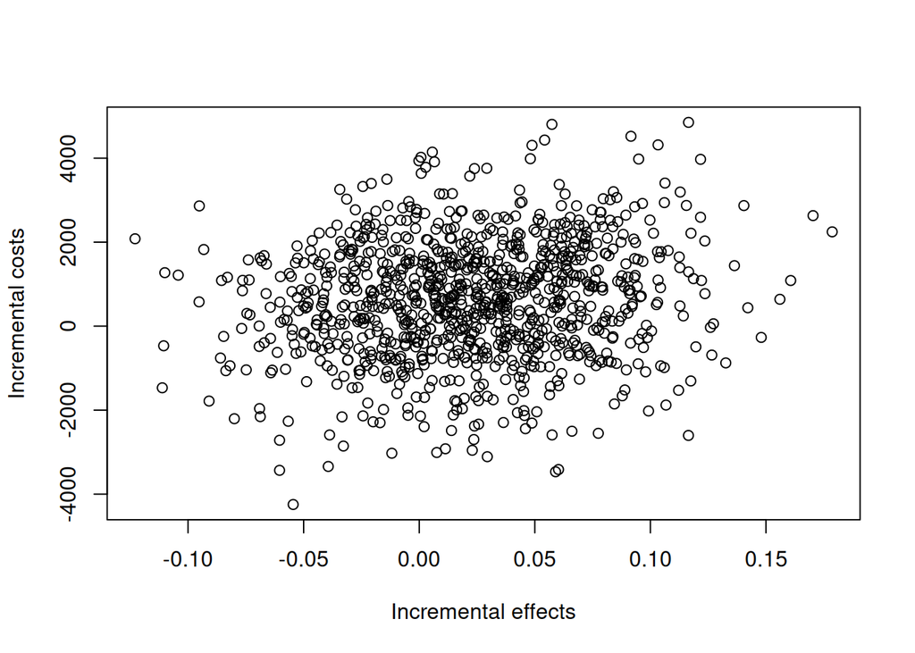

```r
plot(plane, xlab="Incremental effects", ylab="Incremental costs")
```

**Add two solid lines to this plane, one representing a willingness-to-pay (WTP) threshold of €20,000 per QALY gained, and one representing a willingness-to-pay threshold of €80,000 per QALY gained.**

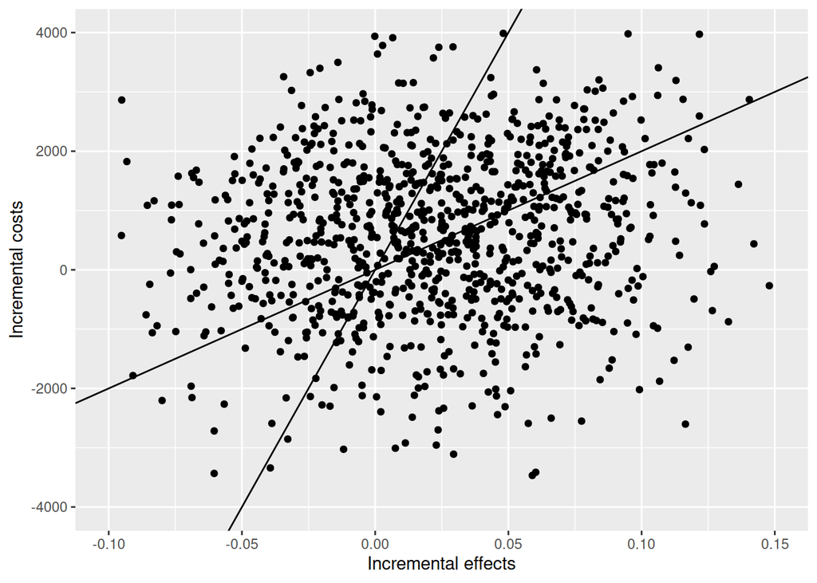

```r
WTP_plot
```

**Determine how many of the PSA samples fall below these respective WTP thresholds.**

```r
percentage_below_20000
```

```
## [1] 0.44
```

```r
percentage_below_80000
```

```
## [1] 0.618
```

**Finally, vary the WTP from €0 to €200,000 per QALY, in steps of €1,000, and determine for each WTP value the fraction of samples (points) falling below that specific WTP. This fraction represents the probability that the intervention strategy has acceptable cost-effectiveness compared with the control strategy, given that specific WTP. Create a cost-effectiveness acceptability curve (CEAC) that visualizes this probability as a function of the WTP over this range. Also, provide correct labels for both axes.**

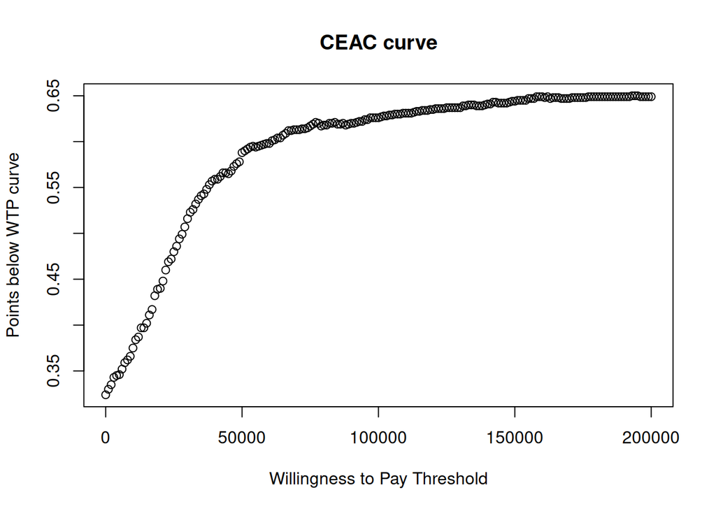

```r
plot(x=seq(0, 200000, length.out = 201), y=percentages_vector, xlab="Willingness to Pay Threshold",
  ylab="Points below WTP curve", main="CEAC curve")
```

**What is your conclusion based on this CEAC?**